# ExtraaLearn Project

## Context

The EdTech industry has been surging in the past decade immensely, and according to a forecast, the Online Education market would be worth $286.62bn by 2023 with a compound annual growth rate (CAGR) of 10.26% from 2018 to 2023. The modern era of online education has enforced a lot in its growth and expansion beyond any limit. Due to having many dominant features like ease of information sharing, personalized learning experience, transparency of assessment, etc, it is now preferable to traditional education.

In the present scenario due to the Covid-19, the online education sector has witnessed rapid growth and is attracting a lot of new customers. Due to this rapid growth, many new companies have emerged in this industry. With the availability and ease of use of digital marketing resources, companies can reach out to a wider audience with their offerings. The customers who show interest in these offerings are termed as leads. There are various sources of obtaining leads for Edtech companies, like

- The customer interacts with the marketing front on social media or other online platforms.
- The customer browses the website/app and downloads the brochure
- The customer connects through emails for more information.

The company then nurtures these leads and tries to convert them to paid customers. For this, the representative from the organization connects with the lead on call or through email to share further details.

## Objective

ExtraaLearn is an initial stage startup that offers programs on cutting-edge technologies to students and professionals to help them upskill/reskill. With a large number of leads being generated on a regular basis, one of the issues faced by ExtraaLearn is to identify which of the leads are more likely to convert so that they can allocate resources accordingly. You, as a data scientist at ExtraaLearn, have been provided the leads data to:

- Analyze and build an ML model to help identify which leads are more likely to convert to paid customers,
- Find the factors driving the lead conversion process
- Create a profile of the leads which are likely to convert

## Data Description

The data contains the different attributes of leads and their interaction details with ExtraaLearn. The detailed data dictionary is given below.

**Data Dictionary**

- ID: ID of the lead
- age: Age of the lead
- current_occupation: Current occupation of the lead. Values include 'Professional','Unemployed',and 'Student'
- first_interaction: How did the lead first interacted with ExtraaLearn. Values include 'Website', 'Mobile App'
- profile_completed: What percentage of profile has been filled by the lead on the website/mobile app. Values include Low - (0-50%), Medium - (50-75%), High (75-100%)
- website_visits: How many times has a lead visited the website
- time_spent_on_website: Total time spent on the website
- page_views_per_visit: Average number of pages on the website viewed during the visits.
- last_activity: Last interaction between the lead and ExtraaLearn.
  - Email Activity: Seeking for details about program through email, Representative shared information with lead like brochure of program , etc
  - Phone Activity: Had a Phone Conversation with representative, Had conversation over SMS with representative, etc
  - Website Activity: Interacted on live chat with representative, Updated profile on website, etc
- print_media_type1: Flag indicating whether the lead had seen the ad of ExtraaLearn in the Newspaper.
- print_media_type2: Flag indicating whether the lead had seen the ad of ExtraaLearn in the Magazine.
- digital_media: Flag indicating whether the lead had seen the ad of ExtraaLearn on the digital platforms.
- educational_channels: Flag indicating whether the lead had heard about ExtraaLearn in the education channels like online forums, discussion threads, educational websites, etc.
- referral: Flag indicating whether the lead had heard about ExtraaLearn through reference.
- status: Flag indicating whether the lead was converted to a paid customer or not.

## Importing necessary libraries and data

```python
import pandas as pd
import numpy as np
import matplotlib.pyplot as plt
import seaborn as sns

# To scale the data using z-score
from sklearn.preprocessing import StandardScaler

from sklearn.model_selection import train_test_split

# Algorithms to be used

from sklearn.tree import DecisionTreeClassifier

from sklearn.tree import plot_tree

from sklearn.ensemble import RandomForestClassifier

# Metrics to evaluate the model
from sklearn import metrics
from sklearn.metrics import confusion_matrix, classification_report, recall_score
from sklearn import tree


# For tuning the model
from sklearn.model_selection import GridSearchCV

# To ignore warnings
import warnings
warnings.filterwarnings("ignore")
```

```python
# I load the dataset
df = pd.read_csv('ExtraaLearn.csv')
```

```python
# Let's check it out
df.head()
```

|  | ID | age | current_occupation | first_interaction | profile_completed | website_visits | time_spent_on_website | page_views_per_visit | last_activity | print_media_type1 | print_media_type2 | digital_media | educational_channels | referral | status |
| --- | --- | --- | --- | --- | --- | --- | --- | --- | --- | --- | --- | --- | --- | --- | --- |
| 0 | EXT001 | 57 | Unemployed | Website | High | 7 | 1639 | 1.861 | Website Activity | Yes | No | Yes | No | No | 1 |
| 1 | EXT002 | 56 | Professional | Mobile App | Medium | 2 | 83 | 0.320 | Website Activity | No | No | No | Yes | No | 0 |
| 2 | EXT003 | 52 | Professional | Website | Medium | 3 | 330 | 0.074 | Website Activity | No | No | Yes | No | No | 0 |
| 3 | EXT004 | 53 | Unemployed | Website | High | 4 | 464 | 2.057 | Website Activity | No | No | No | No | No | 1 |
| 4 | EXT005 | 23 | Student | Website | High | 4 | 600 | 16.914 | Email Activity | No | No | No | No | No | 0 |

## Data Overview

- Observations
- Sanity checks

```python
# Let's have a general look at the dataset
df.info()
```

```
<class 'pandas.core.frame.DataFrame'>
RangeIndex: 4612 entries, 0 to 4611
Data columns (total 15 columns):
 #   Column                 Non-Null Count  Dtype
---  ------                 --------------  -----
 0   ID                     4612 non-null   object
 1   age                    4612 non-null   int64
 2   current_occupation     4612 non-null   object
 3   first_interaction      4612 non-null   object
 4   profile_completed      4612 non-null   object
 5   website_visits         4612 non-null   int64
 6   time_spent_on_website  4612 non-null   int64
 7   page_views_per_visit   4612 non-null   float64
 8   last_activity          4612 non-null   object
 9   print_media_type1      4612 non-null   object
 10  print_media_type2      4612 non-null   object
 11  digital_media          4612 non-null   object
 12  educational_channels   4612 non-null   object
 13  referral               4612 non-null   object
 14  status                 4612 non-null   int64
dtypes: float64(1), int64(4), object(10)
memory usage: 540.6+ KB
```

### Observations:

- We have 15 features and 4612 observations.
- It looks like we don't have any missing values.
- Data type of the features:
  - 1 is floating point numbers
  - 4 are integers
  - 10 are objects

```python
# Let's check the unique values in each of the columns
df.nunique()
```

```
ID                       4612
age                        46
current_occupation          3
first_interaction           2
profile_completed           3
website_visits             27
time_spent_on_website    1623
page_views_per_visit     2414
last_activity               3
print_media_type1           2
print_media_type2           2
digital_media               2
educational_channels        2
referral                    2
status                      2
dtype: int64
```

### Observations:

- ID is composed of unique values, as it is and identifier, so it won't add any extra insight to our model, therefore, we should get rid of it.
- There are seven binary columns.
- Most of the dataset seems to be composed of categorical values, judging by the number of unique values on each column.

```python
# Getting rid of ID
df = df.drop(['ID'], axis=1)
```

Now let's create two lists, containing the names of the categorical and numerical columns separately.

```python
# Categorical columns
cat_cols = ['current_occupation', 'first_interaction', 'profile_completed',
       'last_activity', 'print_media_type1', 'print_media_type2',
       'digital_media', 'educational_channels', 'referral', 'status']

# Numerical columns
num_cols = ['age','website_visits','time_spent_on_website','page_views_per_visit']
```

## Exploratory Data Analysis (EDA)

- EDA is an important part of any project involving data.
- It is important to investigate and understand the data better before building a model with it.
- A few questions have been mentioned below which will help you approach the analysis in the right manner and generate insights from the data.
- A thorough analysis of the data, in addition to the questions mentioned below, should be done.

**Questions**

1. Leads will have different expectations from the outcome of the course and the current occupation may play a key role in getting them to participate in the program. Find out how current occupation affects lead status.
2. The company's first impression on the customer must have an impact. Do the first channels of interaction have an impact on the lead status?
3. The company uses multiple modes to interact with prospects. Which way of interaction works best?
4. The company gets leads from various channels such as print media, digital media, referrals, etc. Which of these channels have the highest lead conversion rate?
5. People browsing the website or mobile application are generally required to create a profile by sharing their personal data before they can access additional information.Does having more details about a prospect increase the chances of conversion?

## Data Preprocessing

- Missing value treatment (if needed)
- Feature engineering (if needed)
- Outlier detection and treatment (if needed)
- Preparing data for modeling
- Any other preprocessing steps (if needed)

### Univariate analysis of the numerical variables

```python
# Let's check basic statistics
df[num_cols].describe()
```

|  | age | website_visits | time_spent_on_website | page_views_per_visit |
| --- | --- | --- | --- | --- |
| count | 4612.000000 | 4612.000000 | 4612.000000 | 4612.000000 |
| mean | 46.201214 | 3.566782 | 724.011275 | 3.026126 |
| std | 13.161454 | 2.829134 | 743.828683 | 1.968125 |
| min | 18.000000 | 0.000000 | 0.000000 | 0.000000 |
| 25% | 36.000000 | 2.000000 | 148.750000 | 2.077750 |
| 50% | 51.000000 | 3.000000 | 376.000000 | 2.792000 |
| 75% | 57.000000 | 5.000000 | 1336.750000 | 3.756250 |
| max | 63.000000 | 30.000000 | 2537.000000 | 18.434000 |

### Observations:

- The average **age** of the leads is 46. It ranges from 18, as expected, to 63 years old. It implies a good diversity, but the fact that the mean is a bit high suggests that there are more middle aged leads than youngs ones.
- The leads **visit the website** 3.56 times in average. It ranges from 0 to 30. Just by looking at this table we can deduce that there are probably some outliers, because there is a huge difference between the 75% and the maximum value.
- The **time spent in the website** is 724 on average, although we don't know if it's seconds, minutes or other unit, so we cannot convert it to datetime objects. Its range varies from 0 to 2537, suggesting a high variability.
- The leads **view per visit** an average of 3 pages, ranging from 0 to 18.4. Judging by the distribution, it looks like it contains some outliers.

Let's now have a look at their distributions, in order to extract more conclussions:

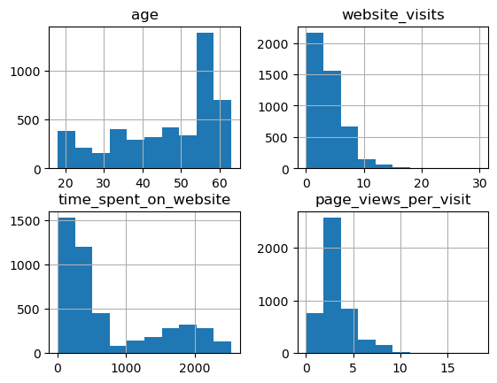

```python
df[num_cols].hist()
plt.show()
```

### Observations:

- **The age distribution** is skewed to the left, showing also a peak on fifty something, which implies a majority of middle aged leads.
- **The number of website visits** is skewed to the right, with a few outliers above 15, and showing that most people don't visit the website, or visit only a few times.
- **The time spent on the website** shows two peaks, one on 0 and the other near 2000. This is an interesting distribution, as it shows that most people spend little time or almost 2000, but few fall in the middle.
- **The pages viewed per visit** shows a peak near 3, and is skewed to the right. Most people only visit a few pages.

I suspect there might be outliers, so let's check it out:

### Univariate analysis of the categorical variables

```python
# Let's see the proportion of each
# of the categories in each variable:
for i in cat_cols:
    print(df[i].value_counts(normalize=True))
    print('·'*50)
```

```
Professional    0.567216
Unemployed      0.312446
Student         0.120338
Name: current_occupation, dtype: float64
··················································
Website       0.551171
Mobile App    0.448829
Name: first_interaction, dtype: float64
··················································
High      0.490893
Medium    0.485906
Low       0.023200
Name: profile_completed, dtype: float64
··················································
Email Activity      0.493929
Phone Activity      0.267563
Website Activity    0.238508
Name: last_activity, dtype: float64
··················································
No     0.892238
Yes    0.107762
Name: print_media_type1, dtype: float64
··················································
No     0.94948
Yes    0.05052
Name: print_media_type2, dtype: float64
··················································
No     0.885733
Yes    0.114267
Name: digital_media, dtype: float64
··················································
No     0.847138
Yes    0.152862
Name: educational_channels, dtype: float64
··················································
No     0.979835
Yes    0.020165
Name: referral, dtype: float64
··················································
0    0.701431
1    0.298569
Name: status, dtype: float64
··················································
```

### Observations:

- **The rate of conversion to paid customers is 29.85%**.
- About **57% are working, 31% are unemployed and 12% are students.** This means that these courses attract mostly people who are already working but need to or want to upskill or reskill.
- **The first interaction** was 55% via website and 45% via mobile app, which is not a significative difference.
- Most people have a highly detailed **profile** (49%) or partially completed (48,5%), leaving a small amount of leads with a sparse profile (2%).
- Most of the **recent activity** goes through email (49%), compared to the website (24%) and phone calls and SMS (27%).
- As for the **ads**:
  - Newspaper: only 11% saw the ad.
  - Magazine: only 5% saw the ad.
  - Digital media: only 11% saw the ad.
  - Educational channels: only 15% saw the ad.
  - Referral: only 2% were referred by someone to ExtraaLearn  
    This seems to indicate that the ad campaigns are not being successful, but people are looking for education and finding the website anyway.

### Multivariate analysis

In this section I'll compare some variables, in order to answer the questions given.

```python
# Let's create a reusable function to make crosstab percentage matrices
def ct_percent (col1, col2):
    ct = pd.crosstab(df[str(col1)],df[str(col2)],normalize='index')*100
    return ct
```

#### 1. Current occupation VS Status

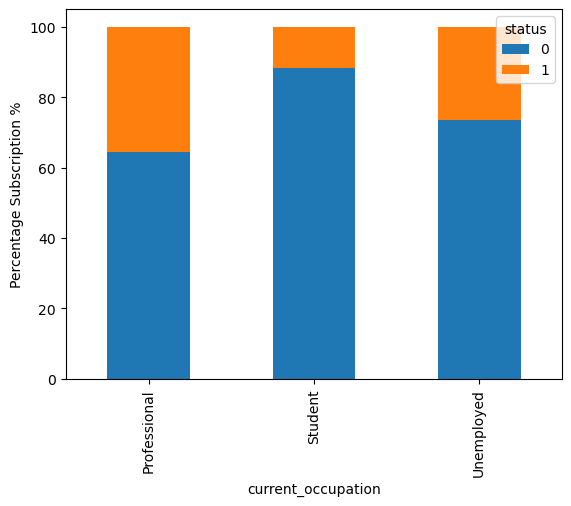

```
status                      0          1
current_occupation
Professional        64.487768  35.512232
Student             88.288288  11.711712
Unemployed          73.421235  26.578765
```

```python
# Let's plot them against each other
ct_percent('current_occupation','status').plot(kind='bar',stacked=True)
plt.ylabel('Percentage Subscription %')
plt.show()
print(ct_percent('current_occupation','status'))
```

#### Observations:

**Professional** seems to be the most impactful, which means that most leads that subscribe are actively working.

#### 2. First interaction VS Status

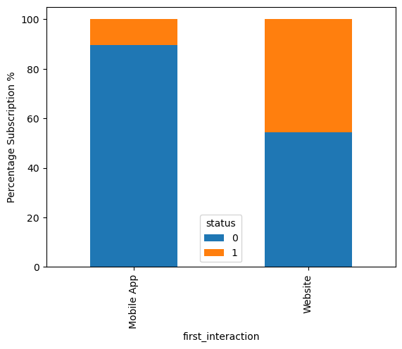

```
status                     0          1
first_interaction
Mobile App         89.468599  10.531401
Website            54.405980  45.594020
```

```python
# Let's plot them against each other
ct_percent('first_interaction','status').plot(kind='bar',stacked=True)
plt.ylabel('Percentage Subscription %')
plt.show()
print(ct_percent('first_interaction','status'))
```

#### 3. Interactions VS Status

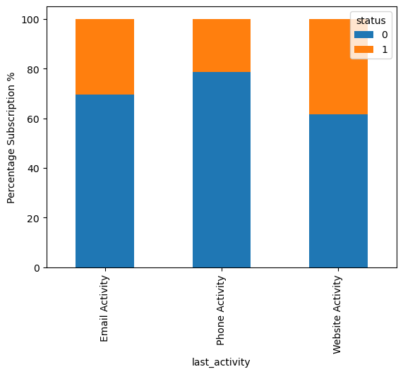

```
status                    0          1
last_activity
Email Activity    69.666374  30.333626
Phone Activity    78.687196  21.312804
Website Activity  61.545455  38.454545
```

```python
# Let's plot them against each other
ct_percent('last_activity','status').plot(kind='bar',stacked=True)
plt.ylabel('Percentage Subscription %')
plt.show()
print(ct_percent('last_activity','status'))
```

#### Observations:

Judging by the last activity recorded, **website** seems to be the most popular among subscribers, followed by **email** and **phone**.

#### 4. Advertising VS Status

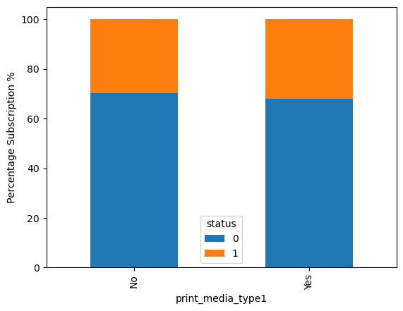

```
status                     0          1
print_media_type1
No                 70.400972  29.599028
Yes                68.008048  31.991952
----------------------------------------------------------
```

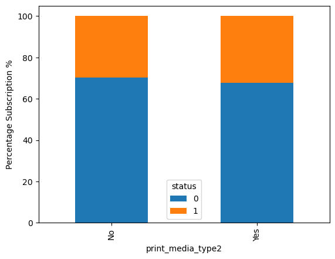

```
status                     0          1
print_media_type2
No                 70.267184  29.732816
Yes                67.811159  32.188841
----------------------------------------------------------
```

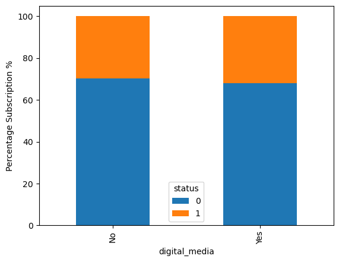

```
status                 0          1
digital_media
No             70.403917  29.596083
Yes            68.121442  31.878558
----------------------------------------------------------
```

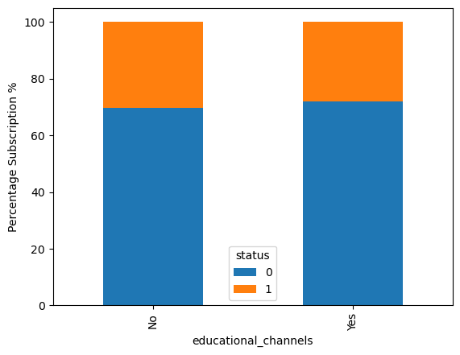

```
status                        0          1
educational_channels
No                    69.797799  30.202201
Yes                   72.056738  27.943262
----------------------------------------------------------
```

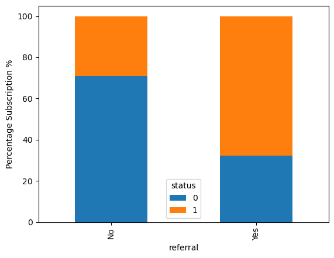

```
status            0          1
referral
No        70.922771  29.077229
Yes       32.258065  67.741935
----------------------------------------------------------
```

```python
# Let's plot them against each other
ad_list = ['print_media_type1','print_media_type2','digital_media','educational_channels','referral']

for i in ad_list:
    ct_percent(i,'status').plot(kind='bar',stacked=True)
    plt.ylabel('Percentage Subscription %')
    plt.show()
    print(ct_percent(i,'status'))
    print('-'*58)
```

#### 5. Profile completeness VS Status

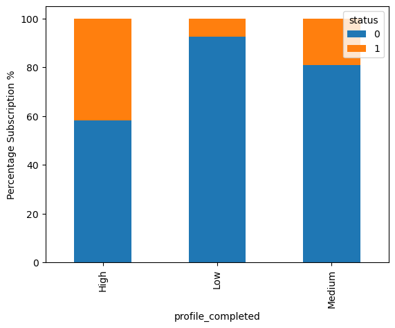

```
status                     0          1
profile_completed
High               58.215548  41.784452
Low                92.523364   7.476636
Medium             81.124498  18.875502
```

```python
# Let's plot them against each other
ct_percent('profile_completed','status').plot(kind='bar',stacked=True)
plt.ylabel('Percentage Subscription %')
plt.show()
print(ct_percent('profile_completed','status'))
```

#### Observations:

As expected, the more complete is the profile, the more likely is for the lead to subscribe, as it shows more interest from the lead.

#### 6. General comparison

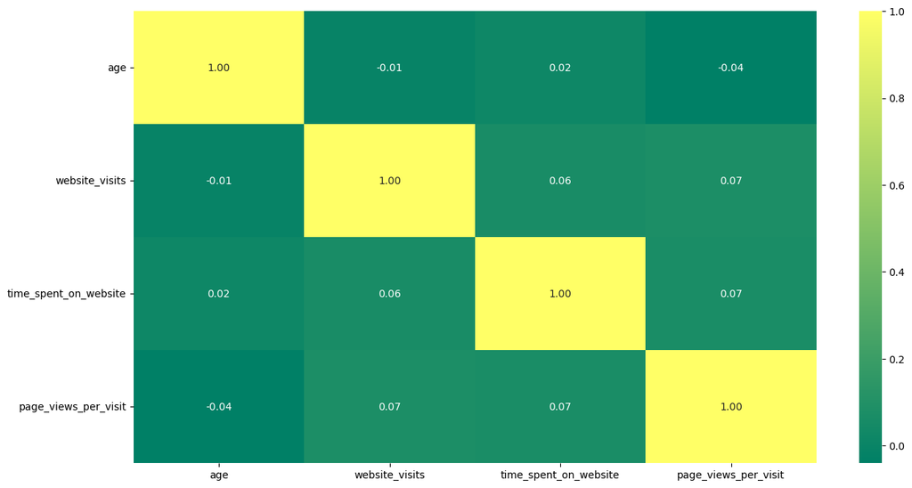

```python
# Let´s plot the correlation between numerical variables
plt.figure(figsize=(15,8))
sns.heatmap(df[num_cols].corr(),annot=True, fmt='0.2f', cmap='summer')
plt.show()
```

As we can see, the correlation between numerical variables is almost nonexistent.

## Data Preprocessing

- Missing value treatment (if needed)
- Feature engineering (if needed)
- Outlier detection and treatment (if needed)
- Preparing data for modeling
- Any other preprocessing steps (if needed)

```python
# Let's create a metric function
def metrics_score(actual, predicted):
    print(classification_report(actual, predicted))

    cm = confusion_matrix(actual, predicted)
    plt.figure(figsize=(8,5))

    sns.heatmap(cm, annot=True,  fmt='.2f', xticklabels=['Not Subscribe', 'Subscribe'], yticklabels=['Not Subscribe', 'Subscribe'])
    plt.ylabel('Actual')
    plt.xlabel('Predicted')
    plt.show()
```

### Missing values

```python
# Let's find out if there are any missing values
df.isnull().sum()
```

```
age                      0
current_occupation       0
first_interaction        0
profile_completed        0
website_visits           0
time_spent_on_website    0
page_views_per_visit     0
last_activity            0
print_media_type1        0
print_media_type2        0
digital_media            0
educational_channels     0
referral                 0
status                   0
dtype: int64
```

#### Observations:

As we can see, there are no missing values in our database.

### Outliers

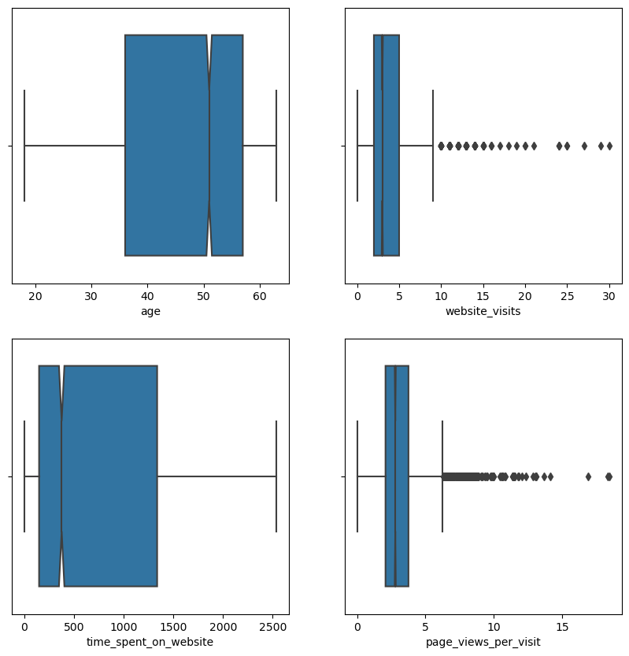

```python
# Let's create four box plots to find the outliers
fig1 , axes = plt.subplots(nrows=2,ncols=2 , figsize = (10,10))
sns.boxplot(df['age'], ax=axes[0,0], notch=True)
sns.boxplot(df['website_visits'], ax=axes[0,1], notch=True)
sns.boxplot(df['time_spent_on_website'], ax=axes[1,0], notch=True)
sns.boxplot(df['page_views_per_visit'], ax=axes[1,1], notch=True)
plt.show()
```

### Observations:

- As we can see, both **website visits** and **pages viewed per visit** present outliers.
- Due to the fact that these variables are the ones used for prediction, and not the target, there should be little to no impact on the result. Therefore, we don't need to treat them (source: https://www.quora.com/What-is-the-impact-of-the-outliers-on-the-decision-tree-algorithm)

### Feature engineering

#### Cardinality

It is recommended the creation of dummy variables when the categorical variables have high cardinality (high number of options), let's check if that's the case.

```python
df[cat_cols].nunique()
```

```
current_occupation      3
first_interaction       2
profile_completed       3
last_activity           3
print_media_type1       2
print_media_type2       2
digital_media           2
educational_channels    2
referral                2
status                  2
dtype: int64
```

#### Observations:

The cardinality is very low, 2 to 3 options per variable, so it's not necessary. But it's recommended for performance and interpretability, so I'll do it:

```python
# Creating list of dummy columns
get_dummies_for = ['current_occupation', 'first_interaction', 'profile_completed', 'last_activity', 'print_media_type1', 'print_media_type2', 'digital_media', 'educational_channels', 'referral']
# Creating dummy variables
df = pd.get_dummies(data = df, columns = get_dummies_for, drop_first = True)
```

#### Binning

According to this article: https://towardsdatascience.com/essential-guide-to-perform-feature-binning-using-a-decision-tree-model-90bcc66d61f9, the best way to perform binning is using a decision tree model. Therefore, that's what I'm going to do.

```python
# Let's create a function that creates our trees
def bins_tree (col1, y):
    # Let's create X and Y
    X_bin = df[[col1]]
    y_bin = df[y]

    # Let's build our decision tree
    params = {'max_depth':[2], 'min_samples_split':[2,3,5,10]}
    dt_bins = DecisionTreeClassifier()
    # And now, we tune it
    clf = GridSearchCV(dt_bins, param_grid=params, scoring='accuracy')
    clf.fit(X_bin, y_bin)
    # And finally create the tree with the parameters
    dt_bins = DecisionTreeClassifier(**clf.best_params_)
    dt_bins = dt_bins.fit(X_bin,y_bin)
    return dt_bins

# This list will contain our trees
trees_binning = []
# We iterate through the list of numerical columns
for i in num_cols:
    tree = bins_tree(i,'status')
    trees_binning.append(tree)
```

```
['age']
```

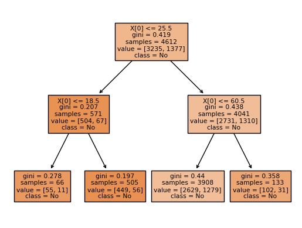

```
++++++++++++++++++++++++++++++++++++++++++++++++++++++++++
['website_visits']
```

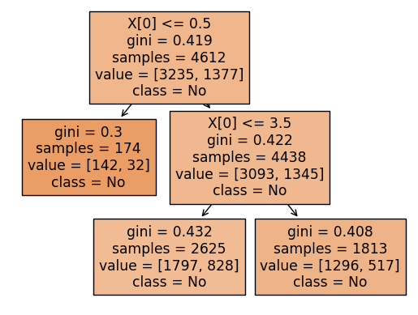

```
++++++++++++++++++++++++++++++++++++++++++++++++++++++++++
['time_spent_on_website']
```

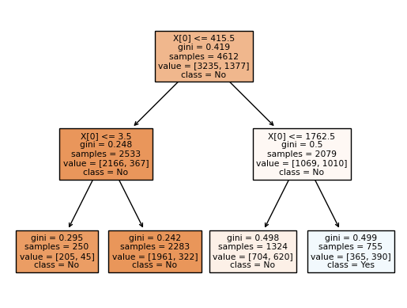

```
++++++++++++++++++++++++++++++++++++++++++++++++++++++++++
['page_views_per_visit']
```

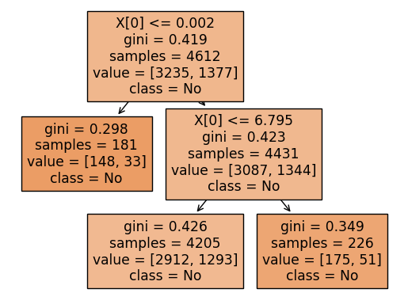

```
++++++++++++++++++++++++++++++++++++++++++++++++++++++++++
```

```python
# Let's plot all the numerical variables to see their configuration
for j in trees_binning:
    plot_tree(j, filled=True, class_names = ['No', 'Yes'])
    print(j.feature_names_in_)
    plt.show()
    print('+'*58)
```

#### Observations:

After carefully revising the trees, and a bit of trial and error, I've come to the conclussion that the only variable that can be split into bins is "time_spent_on_website". The other ones are inconclussive and lead to errors.

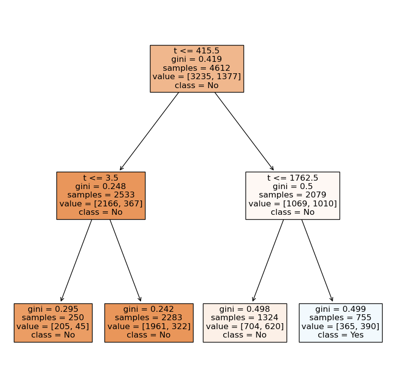

```python
# Let's call the function to create the tree
time_tree = bins_tree('time_spent_on_website','status')

# And plot it
plt.figure(figsize = (10, 10))
plot_tree(time_tree, filled = True, fontsize = 12, feature_names = 'time', class_names = ['No', 'Yes'])
plt.show()
```

#### Observations:

I'll be using the ranges 0-1762.5 and 1762.5-10000 to split the data, since we only observe two classes and that's the threshold between them.

```
              precision    recall  f1-score   support

           0       0.74      0.89      0.81      3235
           1       0.52      0.28      0.37      1377

    accuracy                           0.71      4612
   macro avg       0.63      0.59      0.59      4612
weighted avg       0.68      0.71      0.68      4612
```

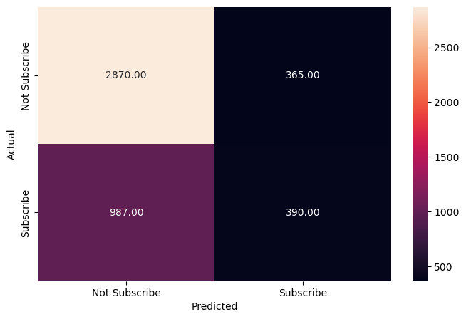

```python
# Let's test the model performance
y_train_pred_time_tree = time_tree.predict(df['time_spent_on_website'].values.reshape(-1, 1))

metrics_score(df['status'], y_train_pred_time_tree)
```

```python
'''# Let´s create the bins, the labels, and pass them to the cut() method, creating a new column with the ranges
bins = [-1, 1762.5, 10000]
# I create two labels and call them 0 and 1
labels = [0, 1]
df['time_bucket'] = pd.cut(df['time_spent_on_website'], bins=bins, labels=labels)

# And now, let's get rid of the old column
df = df.drop(columns=['time_spent_on_website'])'''
```

[output not shown]

#### Observations:

- For **non subscribers**, the model works pretty well
- For **subscribers**, the precision falls to 52%, and the recall is even worse, 28%.  
  This is not a big concern, since it's probably due to the tree being based only on a single variable, and the imbalance in the data.

### Important note:

After trial and error, I realised that adding a binned variable for time spent on the website only decreases the model's performance, hence I decided to leave it commented and don't use it.

#### Feature scaling

```python
# First, let's split the data
Y = df.status
X = df.drop(columns=['status'])
X_train, X_test, y_train, y_test = train_test_split(X, Y, test_size = 0.3, random_state = 1, stratify = Y)
X
```

|  | age | website_visits | time_spent_on_website | page_views_per_visit | current_occupation_Student | current_occupation_Unemployed | first_interaction_Website | profile_completed_Low | profile_completed_Medium | last_activity_Phone Activity | last_activity_Website Activity | print_media_type1_Yes | print_media_type2_Yes | digital_media_Yes | educational_channels_Yes | referral_Yes |
| --- | --- | --- | --- | --- | --- | --- | --- | --- | --- | --- | --- | --- | --- | --- | --- | --- |
| 0 | 57 | 7 | 1639 | 1.861 | 0 | 1 | 1 | 0 | 0 | 0 | 1 | 1 | 0 | 1 | 0 | 0 |
| 1 | 56 | 2 | 83 | 0.320 | 0 | 0 | 0 | 0 | 1 | 0 | 1 | 0 | 0 | 0 | 1 | 0 |
| 2 | 52 | 3 | 330 | 0.074 | 0 | 0 | 1 | 0 | 1 | 0 | 1 | 0 | 0 | 1 | 0 | 0 |
| 3 | 53 | 4 | 464 | 2.057 | 0 | 1 | 1 | 0 | 0 | 0 | 1 | 0 | 0 | 0 | 0 | 0 |
| 4 | 23 | 4 | 600 | 16.914 | 1 | 0 | 1 | 0 | 0 | 0 | 0 | 0 | 0 | 0 | 0 | 0 |
| ... | ... | ... | ... | ... | ... | ... | ... | ... | ... | ... | ... | ... | ... | ... | ... | ... |
| 4607 | 35 | 15 | 360 | 2.170 | 0 | 1 | 0 | 0 | 1 | 1 | 0 | 0 | 0 | 0 | 1 | 0 |
| 4608 | 55 | 8 | 2327 | 5.393 | 0 | 0 | 0 | 0 | 1 | 0 | 0 | 0 | 0 | 0 | 0 | 0 |
| 4609 | 58 | 2 | 212 | 2.692 | 0 | 0 | 1 | 0 | 0 | 0 | 0 | 0 | 0 | 0 | 0 | 0 |
| 4610 | 57 | 1 | 154 | 3.879 | 0 | 0 | 0 | 0 | 1 | 0 | 1 | 1 | 0 | 0 | 0 | 0 |
| 4611 | 55 | 4 | 2290 | 2.075 | 0 | 0 | 1 | 0 | 1 | 1 | 0 | 0 | 0 | 0 | 0 | 0 |

4612 rows × 16 columns

```python
# Let's scale the data
sc=StandardScaler()

# And now fit_transform on train data
X_train_scaled=sc.fit_transform(X_train)
X_train_scaled=pd.DataFrame(X_train_scaled, columns=X.columns)

# Finally, apply transform on test data
X_test_scaled=sc.transform(X_test)
X_test_scaled=pd.DataFrame(X_test_scaled, columns=X.columns)
```

## EDA

- It is a good idea to explore the data once again after manipulating it.

Since we are going to use the scaled data for our tree, let's have a quick look at the distribution.

```
age
```

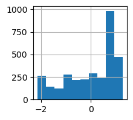

```
website_visits
```

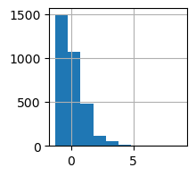

```
time_spent_on_website
```

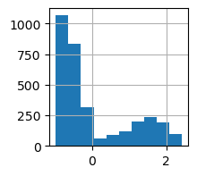

```
page_views_per_visit
```

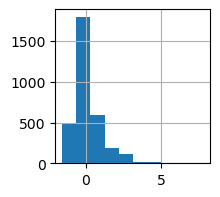

```
current_occupation_Student
```

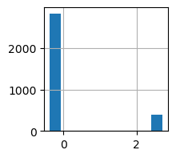

```
current_occupation_Unemployed
```

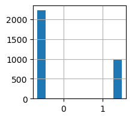

```
first_interaction_Website
```

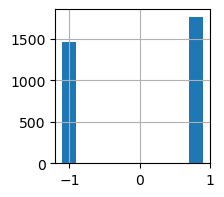

```
profile_completed_Low
```

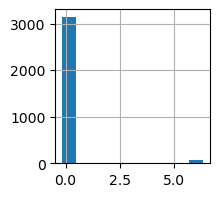

```
profile_completed_Medium
```

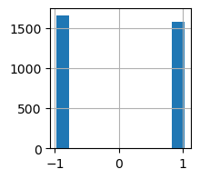

```
last_activity_Phone Activity
```

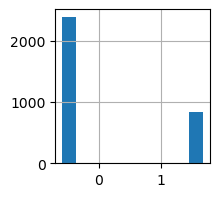

```
last_activity_Website Activity
```

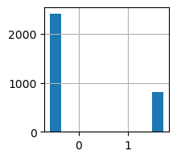

```
print_media_type1_Yes
```

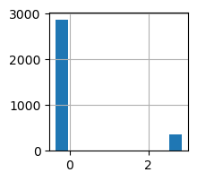

```
print_media_type2_Yes
```

[4 more figures not shown]

```python
for i in X_train_scaled.columns:
    print(i)
    plt.figure(figsize=(2,2))
    X_train_scaled[i].hist()
    plt.show()
```